# Salary_Prediction_Data_Analysis

## SALARY PREDICTION: DESCRIPTIVE and EXPLORATORY DATA ANALYSIS

Problem: The daily manpower recruitment business environment is more dynamic and competitive than it used to be. This causes increased pressure in the hiring process, more importantly in the process of salary negotiations. Therefore, it is reasonable to expect an more risk in offering incorrect figures. If this risk is not eliminated, overestimated salaries can lead to major accumulated financial loss for the company, while underestimated rates can cause financial constraints for employees.

With this given situation, this project aims to make salary predictions that can help facilitate confident decision-making during salary negotiations.

```python
'''import the libraries'''
import pandas as pd
import numpy as np
import matplotlib.pyplot as plt
import seaborn as sns
from sklearn import preprocessing
from sklearn.preprocessing import LabelEncoder
from sklearn.preprocessing import StandardScaler
%matplotlib inline
```

## INSPECT AND CLEANSE DATA

I. LOAD AND SAVE THE GIVEN DATA

```python
pd.options.display.max_columns=None
pd.options.display.max_rows=None

train_df = pd.read_csv('train_features.csv')
target_df = pd.read_csv('train_salaries.csv')
test_df = pd.read_csv('test_features.csv')
xtrain_df = pd.read_csv('xtrain.csv')
```

II. INSPECT THE DATA

```python
train_df.head(5)
```

|  | jobId | companyId | jobType | degree | major | industry | yearsExperience | milesFromMetropolis |
| --- | --- | --- | --- | --- | --- | --- | --- | --- |
| 0 | JOB1362684407687 | COMP37 | CFO | MASTERS | MATH | HEALTH | 10 | 83 |
| 1 | JOB1362684407688 | COMP19 | CEO | HIGH_SCHOOL | NONE | WEB | 3 | 73 |
| 2 | JOB1362684407689 | COMP52 | VICE_PRESIDENT | DOCTORAL | PHYSICS | HEALTH | 10 | 38 |
| 3 | JOB1362684407690 | COMP38 | MANAGER | DOCTORAL | CHEMISTRY | AUTO | 8 | 17 |
| 4 | JOB1362684407691 | COMP7 | VICE_PRESIDENT | BACHELORS | PHYSICS | FINANCE | 8 | 16 |

```python
target_df.head(5)
```

|  | jobId | salary |
| --- | --- | --- |
| 0 | JOB1362684407687 | 130 |
| 1 | JOB1362684407688 | 101 |
| 2 | JOB1362684407689 | 137 |
| 3 | JOB1362684407690 | 142 |
| 4 | JOB1362684407691 | 163 |

```python
test_df.head(5)
```

|  | jobId | companyId | jobType | degree | major | industry | yearsExperience | milesFromMetropolis |
| --- | --- | --- | --- | --- | --- | --- | --- | --- |
| 0 | JOB1362685407687 | COMP33 | MANAGER | HIGH_SCHOOL | NONE | HEALTH | 22 | 73 |
| 1 | JOB1362685407688 | COMP13 | JUNIOR | NONE | NONE | AUTO | 20 | 47 |
| 2 | JOB1362685407689 | COMP10 | CTO | MASTERS | BIOLOGY | HEALTH | 17 | 9 |
| 3 | JOB1362685407690 | COMP21 | MANAGER | HIGH_SCHOOL | NONE | OIL | 14 | 96 |
| 4 | JOB1362685407691 | COMP36 | JUNIOR | DOCTORAL | BIOLOGY | OIL | 10 | 44 |

III. DETERMINE THE VARIABLES, DATA TYPES, AND DATA VOLUME

```python
train_df.info(verbose=True, show_counts=True)
```

```
<class 'pandas.core.frame.DataFrame'>
RangeIndex: 1000000 entries, 0 to 999999
Data columns (total 8 columns):
 #   Column               Non-Null Count    Dtype
---  ------               --------------    -----
 0   jobId                1000000 non-null  object
 1   companyId            1000000 non-null  object
 2   jobType              1000000 non-null  object
 3   degree               1000000 non-null  object
 4   major                1000000 non-null  object
 5   industry             1000000 non-null  object
 6   yearsExperience      1000000 non-null  int64
 7   milesFromMetropolis  1000000 non-null  int64
dtypes: int64(2), object(6)
memory usage: 61.0+ MB
```

```python
target_df.info(verbose=True, show_counts=True)
```

```
<class 'pandas.core.frame.DataFrame'>
RangeIndex: 1000000 entries, 0 to 999999
Data columns (total 2 columns):
 #   Column  Non-Null Count    Dtype
---  ------  --------------    -----
 0   jobId   1000000 non-null  object
 1   salary  1000000 non-null  int64
dtypes: int64(1), object(1)
memory usage: 15.3+ MB
```

```python
test_df.info(verbose=True, show_counts=True)
```

```
<class 'pandas.core.frame.DataFrame'>
RangeIndex: 1000000 entries, 0 to 999999
Data columns (total 8 columns):
 #   Column               Non-Null Count    Dtype
---  ------               --------------    -----
 0   jobId                1000000 non-null  object
 1   companyId            1000000 non-null  object
 2   jobType              1000000 non-null  object
 3   degree               1000000 non-null  object
 4   major                1000000 non-null  object
 5   industry             1000000 non-null  object
 6   yearsExperience      1000000 non-null  int64
 7   milesFromMetropolis  1000000 non-null  int64
dtypes: int64(2), object(6)
memory usage: 61.0+ MB
```

IV: CLEANSE DATA FROM NULLS & DUPLICATES

```python
train_df.isnull().sum()
```

```
jobId                  0
companyId              0
jobType                0
degree                 0
major                  0
industry               0
yearsExperience        0
milesFromMetropolis    0
dtype: int64
```

```python
target_df.isnull().sum()
```

```
jobId     0
salary    0
dtype: int64
```

```python
test_df.isnull().sum()
```

```
jobId                  0
companyId              0
jobType                0
degree                 0
major                  0
industry               0
yearsExperience        0
milesFromMetropolis    0
dtype: int64
```

```python
train_df.duplicated().sum()
```

```
0
```

```python
target_df.duplicated().sum()
```

```
0
```

```python
test_df.duplicated().sum()
```

```
0
```

V. STATISTICAL DESCRIPTIVE ANALYSIS

Describe data statistically. Separate analysis will be done on categorical, numerical variables and salary.

```python
'''Describe the numerical variables: yearsOfExperience, milesFromMetropolis'''
numerical_train_df = train_df[['yearsExperience','milesFromMetropolis']]
numerical_train_df.describe()
```

|  | yearsExperience | milesFromMetropolis |
| --- | --- | --- |
| count | 1000000.000000 | 1000000.000000 |
| mean | 11.992386 | 49.529260 |
| std | 7.212391 | 28.877733 |
| min | 0.000000 | 0.000000 |
| 25% | 6.000000 | 25.000000 |
| 50% | 12.000000 | 50.000000 |
| 75% | 18.000000 | 75.000000 |
| max | 24.000000 | 99.000000 |

The values for the above numerical features: 0 to 24 for 'yearExperience', and 0 to 99 for 'milesFromMetropolis'

```python
'''Describe the categorical variables: companyId, jobType, major, degree, industry'''
categorical_train_df = train_df[['companyId', 'jobType', 'major', 'degree', 'industry']]
categorical_train_df.describe()
```

|  | companyId | jobType | major | degree | industry |
| --- | --- | --- | --- | --- | --- |
| count | 1000000 | 1000000 | 1000000 | 1000000 | 1000000 |
| unique | 63 | 8 | 9 | 5 | 7 |
| top | COMP39 | SENIOR | NONE | HIGH_SCHOOL | WEB |
| freq | 16193 | 125886 | 532355 | 236976 | 143206 |

The features above are best described by count, number of unique groups, top group, and frequency (the number of groups).

```python
'''Describe the train_salaries'''
target_df.describe()
```

|  | salary |
| --- | --- |
| count | 1000000.000000 |
| mean | 116.061818 |
| std | 38.717936 |
| min | 0.000000 |
| 25% | 88.000000 |
| 50% | 114.000000 |
| 75% | 141.000000 |
| max | 301.000000 |

Salary is the dependent feature, or target variable to be predicted.

VI. EXPLORATORY DATA ANALYSIS

Merge train_df and target_df and show first 5 rows:

```python
mdf_train = pd.merge(train_df, target_df, on='jobId')
mdf_train.head()
```

|  | jobId | companyId | jobType | degree | major | industry | yearsExperience | milesFromMetropolis | salary |
| --- | --- | --- | --- | --- | --- | --- | --- | --- | --- |
| 0 | JOB1362684407687 | COMP37 | CFO | MASTERS | MATH | HEALTH | 10 | 83 | 130 |
| 1 | JOB1362684407688 | COMP19 | CEO | HIGH_SCHOOL | NONE | WEB | 3 | 73 | 101 |
| 2 | JOB1362684407689 | COMP52 | VICE_PRESIDENT | DOCTORAL | PHYSICS | HEALTH | 10 | 38 | 137 |
| 3 | JOB1362684407690 | COMP38 | MANAGER | DOCTORAL | CHEMISTRY | AUTO | 8 | 17 | 142 |
| 4 | JOB1362684407691 | COMP7 | VICE_PRESIDENT | BACHELORS | PHYSICS | FINANCE | 8 | 16 | 163 |

VISUALISE AND ANALYSE THE DEPENDENT FEATURE (SALARY)

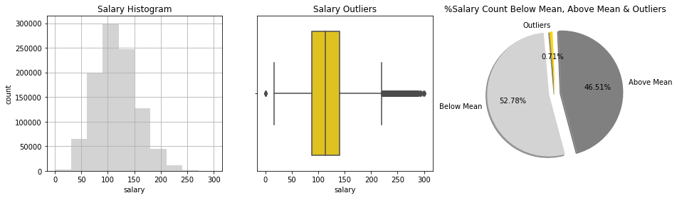

```python
# Set up the matplotlib figure
f, axes = plt.subplots(ncols=3, figsize=(15, 4))
df = mdf_train.copy()
above_mean = df[df['salary']>df['salary'].mean()]

# Graph the Salary distribution
df['salary'].hist(color='lightgray', ax=axes[0], bins=10)
axes[0].set_title("Salary Histogram")
axes[0].set_xlabel('salary')
axes[0].set_ylabel('count')

# Graph the salary outliers
sns.boxplot(df['salary'], color='gold', ax=axes[1]).set_title('Salary Outliers')

# Graph the pie chart
Tasks = [527802, 465081, 7117]
pi_labels = 'Below Mean','Above Mean', 'Outliers'
pi_colors = ['lightgray','gray', 'gold']
pi_explode = (0.1, 0.1, 0)
axes[2].set_title('%Salary Count Below Mean, Above Mean & Outliers')
axes[2].pie(Tasks, labels=pi_labels, autopct='%1.2f%%', startangle=95, shadow = True, colors=pi_colors, explode=pi_explode)
tight=True
```

Descriptive Summary of Salary

```python
df['salary'].describe()
```

```
count    1000000.000000
mean         116.061818
std           38.717936
min            0.000000
25%           88.000000
50%          114.000000
75%          141.000000
max          301.000000
Name: salary, dtype: float64
```

Compute the outlier limits:

```python
salary_statistics = df['salary'].describe()
IQR = salary_statistics['75%']-salary_statistics['25%']
upper_limit = salary_statistics['75%']+1.5*IQR
lower_limit = salary_statistics['25%']-1.5*IQR
print('upper_limt:',upper_limit)
print('lower_limit:',lower_limit)
```

```
upper_limt: 220.5
lower_limit: 8.5
```

The histogram above being lightly skewed to the right, shows that there are more salaries below the mean (mean=116). As seen on the pie chart, this comprises 53% of the data. The boxplot on the 2nd graph presents a better picture of the outliers. Based on percentiles and interquartile range (IQR), the outliers are below 8.5 and above 220.5 of the lower and upper limits respectively. There is a total of 0.71% of outliers as seen on the pie chart

Inspect the lower and higher outliers with boxplot charts

```python
lower_outliers = df[df['salary']<lower_limit]
upper_outliers = df[df['salary']>upper_limit]
```

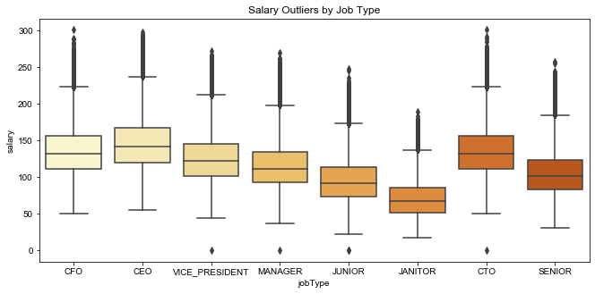

```python
# Graph outliers by job type
f, axes = plt.subplots(figsize=(11, 5))
sns.set_palette('YlOrBr',10)
jobGroup = pd.DataFrame(df.groupby(['jobType'])['salary'].mean())
sns.boxplot(data=jobGroup , x=df['jobType'], y=df['salary']).set_title('Salary Outliers by Job Type')
sns.set_style('white')
tight=True
```

The boxplots show that each job type has outliers. The upper outliers are above the higher horizontal lines, and the lower outliers are plotted below the lowest horizontals. It can be inferred that the JANITOR group has a maximum outlier value that is within the normal range of the higher-mean job type groups. There are also zero salaries found below the lower limit. With these outliers, the decision is to clean the dataset from them or not and can be known by investigating their characteristics.

CHARACTERISTICS OF LOWER OUTLIERS

```python
lower_outliers
```

|  | jobId | companyId | jobType | degree | major | industry | yearsExperience | milesFromMetropolis | salary |
| --- | --- | --- | --- | --- | --- | --- | --- | --- | --- |
| 30559 | JOB1362684438246 | COMP44 | JUNIOR | DOCTORAL | MATH | AUTO | 11 | 7 | 0 |
| 495984 | JOB1362684903671 | COMP34 | JUNIOR | NONE | NONE | OIL | 1 | 25 | 0 |
| 652076 | JOB1362685059763 | COMP25 | CTO | HIGH_SCHOOL | NONE | AUTO | 6 | 60 | 0 |
| 816129 | JOB1362685223816 | COMP42 | MANAGER | DOCTORAL | ENGINEERING | FINANCE | 18 | 6 | 0 |
| 828156 | JOB1362685235843 | COMP40 | VICE_PRESIDENT | MASTERS | ENGINEERING | WEB | 3 | 29 | 0 |

NEW ROWS OF DATA (999,995)

```python
df = df[df['salary']>0]
df.shape
```

```
(999995, 9)
```

CHARACTERISTICS OF UPPER OUTLIERS

```python
upper_outliers.head(10)
```

|  | jobId | companyId | jobType | degree | major | industry | yearsExperience | milesFromMetropolis | salary |
| --- | --- | --- | --- | --- | --- | --- | --- | --- | --- |
| 266 | JOB1362684407953 | COMP30 | CEO | MASTERS | BIOLOGY | OIL | 23 | 60 | 223 |
| 362 | JOB1362684408049 | COMP38 | CTO | MASTERS | NONE | HEALTH | 24 | 3 | 223 |
| 560 | JOB1362684408247 | COMP53 | CEO | MASTERS | BIOLOGY | WEB | 22 | 7 | 248 |
| 670 | JOB1362684408357 | COMP26 | CEO | MASTERS | MATH | AUTO | 23 | 9 | 240 |
| 719 | JOB1362684408406 | COMP54 | VICE_PRESIDENT | DOCTORAL | BIOLOGY | OIL | 21 | 14 | 225 |
| 966 | JOB1362684408653 | COMP32 | CEO | DOCTORAL | ENGINEERING | FINANCE | 23 | 11 | 247 |
| 986 | JOB1362684408673 | COMP37 | CFO | HIGH_SCHOOL | NONE | FINANCE | 24 | 20 | 229 |
| 1211 | JOB1362684408898 | COMP24 | CTO | DOCTORAL | BUSINESS | FINANCE | 5 | 46 | 232 |
| 1222 | JOB1362684408909 | COMP40 | JUNIOR | MASTERS | COMPSCI | OIL | 24 | 5 | 225 |
| 1413 | JOB1362684409100 | COMP56 | VICE_PRESIDENT | MASTERS | MATH | WEB | 24 | 15 | 241 |

The table above shows a few rows of the upper outliers where the salaries are all above the upper limit (220.5). In row 986, both degree and major are NOT typical of CFOs, because this job group often requires higher degree and a related major especially in the finance industry. To validate the accuracy of this data is beyond the scope of this project, particularly that these types of entries are classified and confidential information. Whereas data have natural variations, then this outlier will be considered as exhibiting such, and will not be deleted. Another interesting data is in row 1222 where a "JUNIOR’s" salary is at par with the CEO’s, CFO’s, CTO’s, and VICE_PRESIDENT’s. Further analysis will be done to validate this outlier.

CHARACTERISTICS OF JUNIOR OUTLIERS

```python
junior_outliers = upper_outliers[upper_outliers['jobType']=='JUNIOR']
junior_outliers
```

|  | jobId | companyId | jobType | degree | major | industry | yearsExperience | milesFromMetropolis | salary |
| --- | --- | --- | --- | --- | --- | --- | --- | --- | --- |
| 1222 | JOB1362684408909 | COMP40 | JUNIOR | MASTERS | COMPSCI | OIL | 24 | 5 | 225 |
| 27710 | JOB1362684435397 | COMP21 | JUNIOR | DOCTORAL | ENGINEERING | OIL | 24 | 3 | 246 |
| 31355 | JOB1362684439042 | COMP45 | JUNIOR | DOCTORAL | COMPSCI | FINANCE | 24 | 0 | 225 |
| 100042 | JOB1362684507729 | COMP17 | JUNIOR | DOCTORAL | BUSINESS | FINANCE | 23 | 8 | 248 |
| 160333 | JOB1362684568020 | COMP18 | JUNIOR | DOCTORAL | BUSINESS | FINANCE | 22 | 3 | 223 |
| 189582 | JOB1362684597269 | COMP32 | JUNIOR | DOCTORAL | BUSINESS | OIL | 24 | 11 | 221 |
| 214606 | JOB1362684622293 | COMP47 | JUNIOR | MASTERS | BUSINESS | FINANCE | 22 | 4 | 222 |
| 303778 | JOB1362684711465 | COMP51 | JUNIOR | MASTERS | ENGINEERING | WEB | 24 | 2 | 226 |
| 348354 | JOB1362684756041 | COMP56 | JUNIOR | DOCTORAL | ENGINEERING | OIL | 23 | 25 | 226 |
| 427593 | JOB1362684835280 | COMP54 | JUNIOR | DOCTORAL | ENGINEERING | FINANCE | 23 | 3 | 221 |
| 500739 | JOB1362684908426 | COMP40 | JUNIOR | DOCTORAL | ENGINEERING | OIL | 21 | 0 | 227 |
| 627534 | JOB1362685035221 | COMP5 | JUNIOR | DOCTORAL | ENGINEERING | OIL | 24 | 29 | 230 |
| 645555 | JOB1362685053242 | COMP36 | JUNIOR | DOCTORAL | BUSINESS | FINANCE | 24 | 1 | 225 |
| 656572 | JOB1362685064259 | COMP28 | JUNIOR | DOCTORAL | BUSINESS | OIL | 22 | 3 | 222 |
| 685775 | JOB1362685093462 | COMP38 | JUNIOR | BACHELORS | ENGINEERING | OIL | 24 | 13 | 225 |
| 743326 | JOB1362685151013 | COMP14 | JUNIOR | DOCTORAL | BUSINESS | FINANCE | 19 | 0 | 236 |
| 787674 | JOB1362685195361 | COMP43 | JUNIOR | DOCTORAL | BUSINESS | FINANCE | 18 | 15 | 232 |
| 796956 | JOB1362685204643 | COMP30 | JUNIOR | MASTERS | BUSINESS | OIL | 24 | 2 | 228 |
| 855219 | JOB1362685262906 | COMP13 | JUNIOR | MASTERS | ENGINEERING | OIL | 22 | 26 | 225 |
| 954368 | JOB1362685362055 | COMP11 | JUNIOR | DOCTORAL | BUSINESS | OIL | 24 | 26 | 223 |

CHARACTERISTICS OF NON-OUTLIER JUNIORS

```python
junior_df = df[df['jobType']=='JUNIOR']
junior_df = junior_df[(junior_df['degree']=='DOCTORAL') & (junior_df['major'].isin(['ENGINEERING', 'BUSINESS']))
            & (junior_df['industry'].isin(['OIL','FINANCE','WEB'])) & (junior_df['yearsExperience']>21)
            & (junior_df['yearsExperience']>21) ]
junior_df.head(20)
```

|  | jobId | companyId | jobType | degree | major | industry | yearsExperience | milesFromMetropolis | salary |
| --- | --- | --- | --- | --- | --- | --- | --- | --- | --- |
| 526 | JOB1362684408213 | COMP17 | JUNIOR | DOCTORAL | ENGINEERING | WEB | 23 | 57 | 178 |
| 2386 | JOB1362684410073 | COMP17 | JUNIOR | DOCTORAL | ENGINEERING | FINANCE | 24 | 46 | 168 |
| 2982 | JOB1362684410669 | COMP3 | JUNIOR | DOCTORAL | BUSINESS | FINANCE | 22 | 20 | 192 |
| 5938 | JOB1362684413625 | COMP22 | JUNIOR | DOCTORAL | BUSINESS | FINANCE | 23 | 99 | 116 |
| 10322 | JOB1362684418009 | COMP46 | JUNIOR | DOCTORAL | BUSINESS | OIL | 22 | 68 | 120 |
| 15724 | JOB1362684423411 | COMP43 | JUNIOR | DOCTORAL | BUSINESS | OIL | 22 | 70 | 110 |
| 16414 | JOB1362684424101 | COMP40 | JUNIOR | DOCTORAL | BUSINESS | FINANCE | 24 | 28 | 169 |
| 21267 | JOB1362684428954 | COMP4 | JUNIOR | DOCTORAL | ENGINEERING | WEB | 22 | 51 | 180 |
| 25671 | JOB1362684433358 | COMP46 | JUNIOR | DOCTORAL | ENGINEERING | FINANCE | 23 | 57 | 124 |
| 25757 | JOB1362684433444 | COMP13 | JUNIOR | DOCTORAL | BUSINESS | OIL | 22 | 91 | 118 |
| 27710 | JOB1362684435397 | COMP21 | JUNIOR | DOCTORAL | ENGINEERING | OIL | 24 | 3 | 246 |
| 32135 | JOB1362684439822 | COMP0 | JUNIOR | DOCTORAL | BUSINESS | WEB | 24 | 28 | 172 |
| 32892 | JOB1362684440579 | COMP15 | JUNIOR | DOCTORAL | ENGINEERING | OIL | 23 | 86 | 166 |
| 40916 | JOB1362684448603 | COMP61 | JUNIOR | DOCTORAL | BUSINESS | WEB | 24 | 99 | 94 |
| 47523 | JOB1362684455210 | COMP17 | JUNIOR | DOCTORAL | ENGINEERING | OIL | 22 | 55 | 180 |
| 54448 | JOB1362684462135 | COMP15 | JUNIOR | DOCTORAL | ENGINEERING | WEB | 23 | 27 | 170 |
| 56244 | JOB1362684463931 | COMP25 | JUNIOR | DOCTORAL | ENGINEERING | WEB | 22 | 20 | 161 |
| 59600 | JOB1362684467287 | COMP52 | JUNIOR | DOCTORAL | ENGINEERING | OIL | 24 | 33 | 181 |
| 63826 | JOB1362684471513 | COMP4 | JUNIOR | DOCTORAL | BUSINESS | WEB | 23 | 86 | 122 |
| 69417 | JOB1362684477104 | COMP24 | JUNIOR | DOCTORAL | ENGINEERING | OIL | 24 | 19 | 138 |

CONCLUSION ABOUT UPPER OUTLIERS

From the two tables above, JUNIOR group outliers and non-outliers have comparable characteristics therefore, the outliers will not be treated differently from the non-outliers. Overall, none of the upper outliers will be imputed nor removed. As mentioned earlier, datasets have innated natural variations and to remove these outliers can make the dataset appear less variable than it is.

EXPLORATORY DATA ANALYSIS BY VARIABLE (OR CATEGORY)

1. COMPANY (variable name:'companyId')

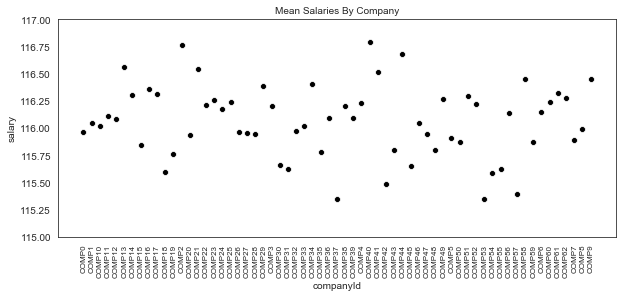

```python
# Set up the matplotlib figure
compGroup = pd.DataFrame(df.groupby(['companyId'])['salary'].mean())

f, axes = plt.subplots(figsize=(10,4))
sns.scatterplot(data=compGroup, x=compGroup.index, y=compGroup['salary'], color='black')
axes.set_title('Mean Salaries By Company', Fontsize=10)
axes.set_ylabel('salary')
axes.set(ylim=(115, 117))
axes.set_xticklabels(compGroup.index, rotation=90, Fontsize=8)
sns.set_style('white')
```

[figure not shown]

```python
# Pie chart rate of employment per company
f, axes = plt.subplots(figsize=(5,5))
compCount = df.groupby(['companyId'])[['salary']].count()
tasks = compCount['salary'].to_list()
pi_labels = compCount['salary'].index.to_list()
axes.set_title("Employment Rate Per Company")
axes.pie(tasks, labels=pi_labels, autopct='%1.2f%%', startangle=90, shadow = True)
tight=True
```

DESCRIPTIVE STATS

```python
np.corrcoef(xtrain_df['companyId'], xtrain_df['salary'])
```

```
array([[1.        , 0.00830897],
       [0.00830897, 1.        ]])
```

```python
compGroup.head()
```

| companyId | salary |
| --- | --- |
| COMP0 | 115.963615 |
| COMP1 | 116.048609 |
| COMP10 | 116.019800 |
| COMP11 | 116.113029 |
| COMP12 | 116.086485 |

The scatterplot above shows the average salaries of 63 company groups found in the dataset. The graph also shows that there is no linear relationship between salary and ‘companyId.’ Thus, in terms of prediction, ‘companyId’ is not a strong predictor for salary. Companies also differ in mean salaries by around 0.20 based on percentiles. In terms of rate of employment, companies apparently almost have equal portions on the pie chart, between 1.58% to 1.60% with very minimal difference of .02%. Regardless of negligible variability and insignificance as a predictor, ‘companyId’ can be useful in future analyses and in creating reports. When paired with other variables like "milesFromMetropolis" for instance, this combination will provide an insight about which companies in the metropolis pay the highest salaries. Or, if a third variable say "industry" is included, an insight about top N companies within the metropolis, paying the highest salaries in the oil industry can be derived.

1. YEARS OF EXPERIENCE (variable name:'yearsExperience')

```python
# Set up the matplotlib figure
def plot(cat, group, xlength):
    f, axes = plt.subplots(ncols=2, figsize=(xlength, 4))
    dfCat = pd.DataFrame(df.groupby([cat])['salary'].mean())

    # plot category and mean salaries
    sns.barplot(data=dfCat, x=dfCat.index, y=dfCat['salary'], color='gray', ax=axes[0])
    axes[0].set_title('Mean Salaries By ''+ cat + ''',Fontsize=12)
    axes[0].set_ylabel('salary')
    axes[0].set_xticklabels(dfCat.index, rotation=90)

    # plot group 'histogram'
    dfGroup = pd.DataFrame(df[df[cat]==group])
    sns.scatterplot(data=dfGroup, x=dfGroup.groupby(['salary'])[cat].count().index.to_list(),
                y=dfGroup.groupby(['salary'])[cat].count().to_list(), color='brown', ax=axes[1])
    axes[1].set_title('Unique Salary Groups for ' + cat + '=' +str(group), Fontsize=12)
    axes[1].set_ylabel('count')
    axes[1].set_xlabel('salary')
    tight=True
```

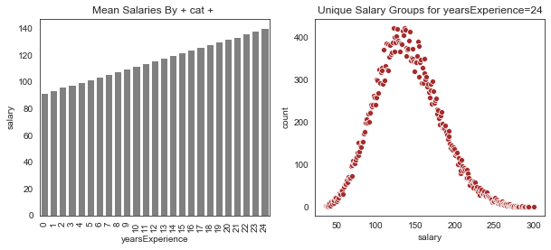

```python
plot('yearsExperience', 24, 10)
```

```python
# create a stats summary
def summaries(xdf, df, cat, group):
    corr = np.corrcoef(xdf[cat], xdf['salary'])
    print ('Correlation Coefficient:\n ', corr)
    print ('\nFor ' + cat + ' = ' + str(group) + ':')
    print ('-------------------------')
    sgdf = pd.DataFrame(df[df[cat]==group])
    print ('Mean Group Salary:', round(sgdf['salary'].mean(),2))
    print ('Total Count of Salaries: ', sgdf['salary'].count())
    print ('Number of unique salaries:',len(sgdf['salary'].unique()))
    print ('Min salary:', sgdf['salary'].min())
    print ('Max salary:', sgdf['salary'].max())
```

```python
summaries(xtrain_df, df, 'yearsExperience', 24)
```

```
Correlation Coefficient:
  [[1.        0.3750134]
 [0.3750134 1.       ]]

For yearsExperience = 24:
-------------------------
Mean Group Salary: 140.13
Total Count of Salaries:  39860
Number of unique salaries: 254
Min salary: 36
Max salary: 301
```

The bar graph for "yearsExperience" provides 3 information as follows: a linear relationship, positive correlation, and weak relationship between “yearsExperience” and salary. When "yearsExperience" increases, salary also increases. This linearity however, does not mean that a unit increase in "yearsExperience" equates to a unit increase in salary. Because the correlation value of 0.38 is generally low, salary can increase by only as much. In terms of prediction, 'yearsExperience' is not a strong predictor based on this value.

The scatter plot (histogram with data points in detail) on the other hand, shows a slightly right-skewed distribution of data where "yearsExperience" is equal to 24. The graph represents 254 unique salary groups that were sorted out from 39,860 individual salaries ranging from 36 to 301.

Note: The "summaries function" is interactive. When the default inputs are modified, this narrative does not apply.

1. DISTANCE FROM METROPOLIS (variable name: milesFromMetropolis)

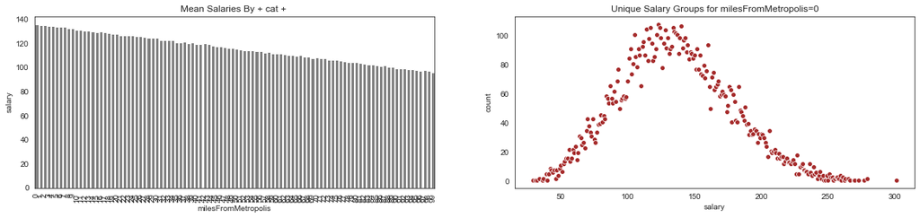

```python
plot('milesFromMetropolis', 0, 20)
```

```python
summaries(xtrain_df, df, 'milesFromMetropolis', 0)
```

```
Correlation Coefficient:
  [[ 1.         -0.29768643]
 [-0.29768643  1.        ]]

For milesFromMetropolis = 0:
-------------------------
Mean Group Salary: 135.57
Total Count of Salaries:  10123
Number of unique salaries: 239
Min salary: 29
Max salary: 301
```

The bar graph above indicates a linear relationship and a negative correlation between salary and "milesFromMetropolis." When a company's distance from the metropolis area increases, salary decreases. The correlation coefficient equal to (-)0.29768643, indicates a weak relationship between the two variables implying that "milesFromMetropolis" is not a strong salary predictor. Note: The "summaries function" above is interactive. When the default inputs are modified, this narrative does not apply.

1. MEAN SALARIES ACCORDING TO JOB TYPE (variable:'jobType')

```python
def plot_categoricals(cat, group, ncols, xlength, ylength):
    f, axes = plt.subplots(ncols=ncols, figsize=(xlength, ylength))
    dfGroup = pd.DataFrame(df.groupby([cat])['salary'].mean())

    sns.set_palette('YlOrBr', 10)
    sns.barplot(data=dfGroup, x=dfGroup.salary.sort_values(ascending=True), y=dfGroup['salary'], ax=axes[0])
    axes[0].set_title('Mean Salaries By ' + cat)
    axes[0].set_ylabel('salary')
    axes[0].set_xticklabels(dfGroup.salary.sort_values(ascending=True).index, rotation=45)
    sns.set_style('white')

    #plot histogram for job type group "SENIOR"
    dfCount = pd.DataFrame(df[df[cat]==group])
    sns.distplot(dfCount['salary'], color='darkorange', ax=axes[1], bins=10)
    axes[1].set_title(group + ' Job Type Salary Histogram')
    axes[1].set_ylabel('frequency')
    axes[1].set_xlabel('salary range for ' + group + ' job type')

    # Graph the pie chart
    tasks = pd.DataFrame(df.groupby([cat])['salary'].count()).salary.to_list()
    pi_labels = pd.DataFrame(df.groupby([cat])['salary'].count()).index.to_list()
    axes[2].set_title('% COUNT BY GROUP')
    axes[2].pie(tasks, labels=pi_labels, autopct='%1.2f%%', startangle=90, shadow = True)
    tight=True
```

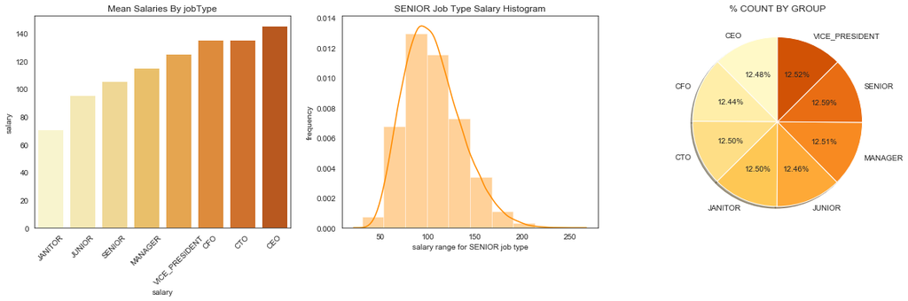

```python
plot_categoricals('jobType', 'SENIOR', 3, 20, 5)
```

```python
summaries(xtrain_df, df, 'jobType', 'SENIOR')
```

```
Correlation Coefficient:
  [[1.         0.57892206]
 [0.57892206 1.        ]]

For jobType = SENIOR:
-------------------------
Mean Group Salary: 105.49
Total Count of Salaries:  125886
Number of unique salaries: 211
Min salary: 31
Max salary: 258
```

The bar graph above shows that there is a linear relationship between "jobType" and salary. The higher one moves up the career ladder, the higher the compensation is. But with a correlation value of 0.58, a change in job type corresponds to only as much increase salary. This is because there is an underlying wide range of salaries per job type that limiting the correlation line to capture as many points from 125,886 individual salaries. As shown in the histogram, SENIOR group salaries range from 31 to 258. Further, these data are grouped into 211 unique salaries and binned accordingly. Lastly, the pie chart shows the percent count for each group.

Note: The "summaries function" is interactive. When the default inputs are modified, this narrative does not apply.

1. MEAN SALARIES BY DEGREE (variable:'degree')

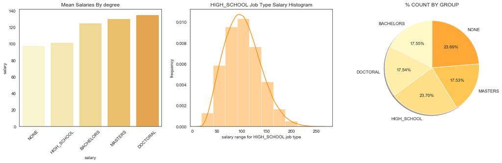

```python
plot_categoricals('degree', 'HIGH_SCHOOL', 3, 20, 5)
```

```python
summaries(xtrain_df, df, 'degree', 'HIGH_SCHOOL')
```

```
Correlation Coefficient:
  [[1.         0.38404385]
 [0.38404385 1.        ]]

For degree = HIGH_SCHOOL:
-------------------------
Mean Group Salary: 101.92
Total Count of Salaries:  236975
Number of unique salaries: 240
Min salary: 18
Max salary: 260
```

The bar graph above shows a linear relationship between degree and salary. Salary increases with one's educational qualification, with NONE (no degree) having the lowest mean salary and 'DOCTORAL' having the highest mean salary. The correlation value (equal to 0.38) is considered weak, in terms of prediction power. The histogram for HIGH_SCHOOL group on the 2nd graph shows an almost normal distribution. The right tail is estimated to be 0.71% of upper outliers based on the descriptive statistics presented earlier. Lastly, the pie chart shows the percentage count for each group.

Note: The "summaries function" is interactive. When the default inputs are modified, this narrative does not apply.

1. MEAN SALARIES BY MAJOR (variable:'major')

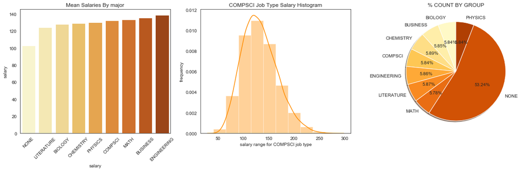

```python
plot_categoricals('major', 'COMPSCI', 3, 20, 5)
```

```python
summaries(xtrain_df, df, 'major', 'COMPSCI' )
```

```
Correlation Coefficient:
  [[1.         0.34621297]
 [0.34621297 1.        ]]

For major = COMPSCI:
-------------------------
Mean Group Salary: 132.08
Total Count of Salaries:  58382
Number of unique salaries: 233
Min salary: 41
Max salary: 286
```

Based on the bar graph for major and salary, there is a linear relationship between the two features. Like degree and salary, salary increases when educational qualification "increases." The correlation value (equal to 0.35) indicates that "major" category has a weak salary prediction power. The histogram for COMPSCI group on the 2nd graph shows an almost normal distribution. Once again, the right tail is estimated to be 0.71% of upper outliers based on the descriptive statistics presented earlier. Lastly, the pie chart shows the percentage count for each group. Note: The "summaries function" is interactive. When the default inputs are modified, this narrative does not apply.

1. MEAN SALARIES BY INDUSTRY (variable:'industry')

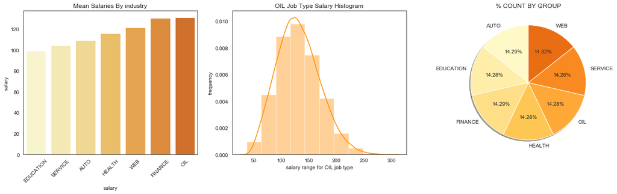

```python
plot_categoricals('industry', 'OIL', 3,20,5)
```

```python
summaries(xtrain_df, df, 'industry', 'OIL' )
```

```
Correlation Coefficient:
  [[1.         0.29389427]
 [0.29389427 1.        ]]

For industry = OIL:
-------------------------
Mean Group Salary: 130.95
Total Count of Salaries:  142770
Number of unique salaries: 255
Min salary: 37
Max salary: 301
```

CORRELATION HEATMAP

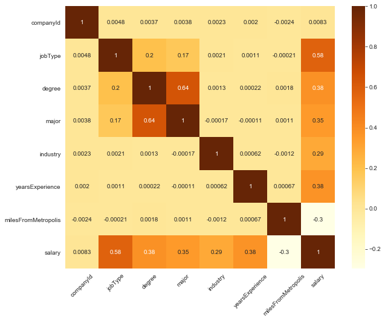

```python
features = ['jobId', 'companyId', 'jobType', 'degree', 'major',
       'industry', 'yearsExperience', 'milesFromMetropolis']
target = 'salary'
fig = plt.figure(figsize=(10, 8))
sns.heatmap(xtrain_df[features + [target]].corr(), cmap='YlOrBr', annot=True)
plt.xticks(rotation=45)
plt.show()
```